# Chapter 11

## Neural Nets

In this chapter, we describe neural networks, a flexible data-driven method that can be used for classification or prediction. Although considered a “blackbox” in terms of interpretability, neural nets have been highly successful in terms of predictive accuracy.

We discuss the concepts of:

- nodes
- layers

We describe the different parameters that a user must specify and explain the effect of each on the process. Finally, we discuss the usefulness of neural nets and their limitations.

### Introduction

Neural networks, also called **artificial neural networks**, are models for classification and prediction. They mimic the way that human experts learn. The learning and memory properties of neural networks resemble the properties of human learning and memory, and they also have a capacity to generalize from particulars. The main strength of neural networks is their high predictive performance. Their structure supports capturing very complex relationships between predictors and an outcome variable, which is often not possible with other predictive models.

### Concept and Structure of a Neural Network

The idea behind neural networks is to combine the predictor information in a very flexible way that captures complicated relationships among these variables and between them and the outcome variable. In linear regression modeling we might try different transformations of the predictors, interactions between predictors, and so on, but the specified form of the relationship remains linear. In comparison, in neural networks the user is not required to specify the correct form. Instead, the network tries to learn about such relationships from the data. In fact, linear regression and logistic regression can be thought of as special cases of very simple neural networks that have only input and output layers and no hidden layers.

Although researchers have studied numerous different neural network architectures, the most successful applications of neural networks in data mining have been **multilayer feedforward networks**. These are networks in which there is an input layer consisting of nodes (sometimes called **neurons**) that simply accept the predictor values, and successive layers of nodes that receive input from the previous layers. The outputs of nodes in each layer are inputs to nodes in the next layer. The last layer is called the output layer. Layers between the input and output layers are known as hidden layers

A feedforward network is a fully connected network with a one-way flow and no cycles. Figure below shows a diagram for this architecture, with two hidden layers and one node in the output layer representing the outcome value to be predicted. In a classification problem with m classes, there would be **m** output nodes (or **m − 1** output nodes, depending on the software).

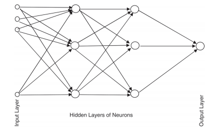

### Fitting a Network to Data

Consider the following very small dataset. Table 11.1 includes information on a tasting score for a certain processed cheese. The two predictors are scores for fat and salt, indicating the relative presence of fat and salt in the particular cheese sample (where 0 is the minimum amount possible in the manufacturing process, and 1 the maximum). The outcome variable is the cheese sample’s consumer taste preference, where like or dislike indicate whether the consumer likes the cheese or not.

Nodes 1 and 2 belong to the input layer, nodes 3 to 5 belong to the hidden layer, and nodes 6 and 7 belong to the output layer. The values on the connecting arrows are called weights, and the weight on the arrow from node i to node j is denoted by wi,j . The additional bias nodes, denoted by θj , serve as an intercept for the output from node j. These are all explained in further detail below.

```r
scores <- read.csv("scores.csv")
scores
```

```
##   Obs Fat Salt Acceptance
## 1   1 0.2  0.9       like
## 2   2 0.1  0.1    dislike
## 3   3 0.2  0.4    dislike
## 4   4 0.2  0.5    dislike
## 5   5 0.4  0.5       like
## 6   6 0.3  0.8       like
```

### Computing Output of Nodes

We discuss the input and output of the nodes separately for each of the three types of layers (input, hidden, and output). The main difference is the function used to map from the input to the output of the node. Input nodes take as input the values of the predictors. Their output is the same as the input. If we have p predictors, the input layer will usually include p nodes. In our example, there are two predictors, and therefore the input layer (shown in Figure 11.2) includes two nodes, each feeding into each node of the hidden layer. Consider the first record: The input into the input layer is Fat = 0.2 and Salt = 0.9, and the output of this layer is also x1 = 0.2 and x2 = 0.9. Hidden layer nodes take as input the output values from the input layer. The hidden layer in this example consists of three nodes, each receiving input from all the input nodes. To compute the output of a hidden layer node, we compute a weighted sum of the inputs and apply a certain function to it.

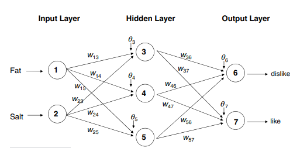

**NEURAL NETWORK FOR THE EXAMPLE. CIRCLES REPRESENT NODES (“NEURONS”), Wi,j ON ARROWS ARE WEIGHTS, AND θj ARE NODE BIAS VALUES**

More formally, for a set of input values x1, x2, . . . , xp, we compute the output of node j by taking the weighted sum1 θj + ∑p i=1 wijxi , where θj , w1,j , . . . , wp,j are weights that are initially set randomly, then adjusted as the network “learns.” Note that θj , also called the bias of node j, is a constant that controls the level of contribution of node j. In the next step, we take a function g of this sum. The function g, also called a transfer function or activation function is some monotone function. Examples include the linear function [g(s) = bs], an exponential function [g(s) = exp(bs)], and a logistic/sigmoidal function [g(s) = 1/1 + e −s].

This last function is by far the most popular one in neural networks. Its practical value arises from the fact that it has a squashing effect on very small or very large values but is almost linear in the range where the value of the function is between 0.1 and 0.9

If we use a logistic activation function, we can write the output of node j in the hidden layer as

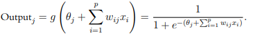

**Initializing the Weights**

The values of θj and wij are initialized to small, usually random, numbers (typically, but not always, in the range 0.00 ± 0.05). Such values represent a state of no knowledge by the network, similar to a model with no predictors. The initial weights are used in the first round of training. Returning to our example, suppose that the initial weights for node 3 are θ3 = −0.3, w1,3 = 0.05, and w2,3 = 0.01

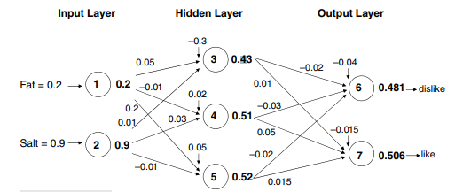

**COMPUTING NODE OUTPUTS (IN BOLDFACE TYPE) USING THE FIRST RECORD IN THE EXAMPLE AND A LOGISTIC FUNCTION**

Using the logistic function, we can compute the output of node 3 in the hidden layer (using the first record) as

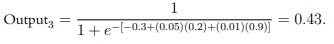

Finally, the output layer obtains input values from the (last) hidden layer. It applies the same function as above to create the output. In other words, it takes a weighted sum of its input values and then applies the function g. In our example, output nodes 6 and 7 receive input from the three hidden layer nodes. We can compute the output of these nodes by

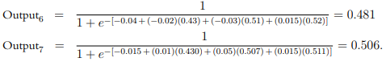

These two numbers are *almost* the propensities P(Y = dislike | Fat = 0.2, Salt = 0.9) and P(Y = like | Fat = 0.2. Salt = 0.9). The last step involves normalizing these two values so that they add up to 1.

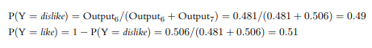

**Training the Model**

Training the model means estimating the weights θj and wij that lead to the best predictive results. For each record, the model produces a prediction which is then compared with the actual outcome value. Their difference is the error for the output node. In particular, the error for the output node is distributed across all the hidden nodes that led to it, so that each node is assigned “responsibility” for part of the error. Each of these node-specific errors is then used for updating the weights.

**Back Propagation of Error**

Let us examine the output from running a neural network on our data. Following Figures above, we used a single hidden layer with three nodes. R has several packages for neural nets, the most common ones are nnet and neuralnet (note that package nnet does not enable multilayer networks and has no plotting option). We used neuralnet in this example. The weights and model output are shown in tabels shows these weights in a format similar to that of our previous diagrams.

```r
library(neuralnet)
nn <- neuralnet( Acceptance ~ Salt + Fat, data = scores, linear.output = F, hidden = 3)
# display weights
nn$weights
```

```
## [[1]]
## [[1]][[1]]
##           [,1]      [,2]      [,3]
## [1,]  2.231720  1.911224  2.471090
## [2,] -3.837299 -3.010177 -3.478738
## [3,] -5.450035 -5.692949 -5.901830
##
## [[1]][[2]]
##           [,1]      [,2]
## [1,] -5.604423  5.261066
## [2,]  8.462799 -5.721267
## [3,]  8.252737 -8.420026
## [4,]  6.510895 -7.369542
```

```r
# display predictions
prediction(nn)
```

```
## Data Error:  0;
```

```
## $rep1
##   Salt Fat       like      dislike
## 1  0.1 0.1 0.99999629 9.914790e-06
## 2  0.4 0.2 0.98443395 2.064890e-02
## 3  0.5 0.2 0.90701185 1.046660e-01
## 4  0.9 0.2 0.05169943 9.354905e-01
## 5  0.8 0.3 0.03213451 9.594269e-01
## 6  0.5 0.4 0.09090484 8.969006e-01
##
## $data
##   Salt Fat like dislike
## 1  0.1 0.1    1       0
## 2  0.4 0.2    1       0
## 3  0.5 0.2    1       0
## 4  0.9 0.2    0       1
## 5  0.8 0.3    0       1
## 6  0.5 0.4    0       1
```

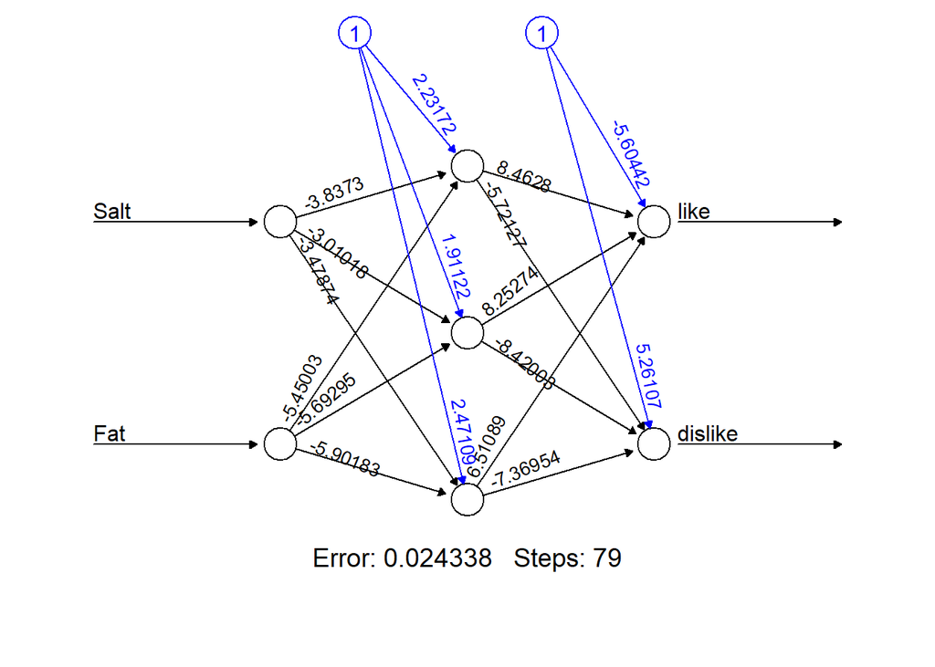

```r
# plot network
plot(nn, rep="best")
```

We use the weights in the way we described earlier to compute the hidden layer’s output. For instance, for the first record, the output of our previous node 3 is:

[figure not shown]

[figure not shown]

```r
library(caret)
```

```r
library(lattice)
library(ggplot2)
predict <- compute(nn, data.frame(scores$Salt, scores$Fat))
predicted.class=apply(predict$net.result,1,which.max)-1

confusionMatrix(
  factor(ifelse(predicted.class=="1", "dislike", "like"), levels = 1:2),
  factor(scores$Acceptance, levels = 1:2)
)
```

```
## Confusion Matrix and Statistics
##
##           Reference
## Prediction 1 2
##          1 0 0
##          2 0 0
##
##                Accuracy : NaN
##                  95% CI : (NA, NA)
##     No Information Rate : NA
##     P-Value [Acc > NIR] : NA
##
##                   Kappa : NaN
##
##  Mcnemar's Test P-Value : NA
##
##             Sensitivity :  NA
##             Specificity :  NA
##          Pos Pred Value :  NA
##          Neg Pred Value :  NA
##              Prevalence : NaN
##          Detection Rate : NaN
##    Detection Prevalence : NaN
##       Balanced Accuracy :  NA
##
##        'Positive' Class : 1
##
```